# Geothermodynamics

Jennifer Reeve

August 28, 2018

# Class notes

## Aug 27 2018

R$\rightleftharpoons$ P

$[\frac{^{34}S}{^{32}S}]_{reactant}/[\frac{^{34}S}{^{32}S}]_{product}=^{34}\alpha_{R,P}$ aka the fractionation factor

$^{34}\alpha_{R,P}=(^{34}\alpha^{EQ}_{R,P}- ^{34}\alpha^{Kin}_{R,P})\frac{\phi_{P,R}}{\phi_{R,P}}+ ^{34}\alpha^{Kin}_{R,P}$

Where $\frac{\phi_{P,R}}{\phi_{R,P}}$ represents the back reaction (numerator) divided by the forward reaction (denominator). It is also true that $\frac{\phi_{P,R}}{\phi_{R,P}}=e^{\frac{\Delta G_r}{RT}}$.

## Aug 29 2018

Thermodynamics terms:

### System:

1. observer defined, separate from the rest of the universe (ROU)
2. nature of the boundary between the system and the ROU defines the system type
   1. open: mass and energy can cross the boundary. Example: hydrothermal ore system
   2. closed: energy may cross but not mass
   3. adiabatic: no heat energy may cross. Example: developing clouds or ascending magma
   4. isolated: neither heat nor mass may cross

Can think of a system as a collection of phases (see below)

### Phase:

substance with uniform chemical and physical properties or properties that smoothly vary

1. minerals: each type is a potential phase
2. liquids: silicate melts, aqueous solutions, glasses
3. gases:
4. fluids: gas/liquid above a “critical” point

most phases we encounter are solutions with varying chemical compositions, not pure solutions.

example: plagioclase feldspar: imagine that the green in the image is anorithite (Ca-rich feldspar) and the red is albite (Na-rich feldspar)

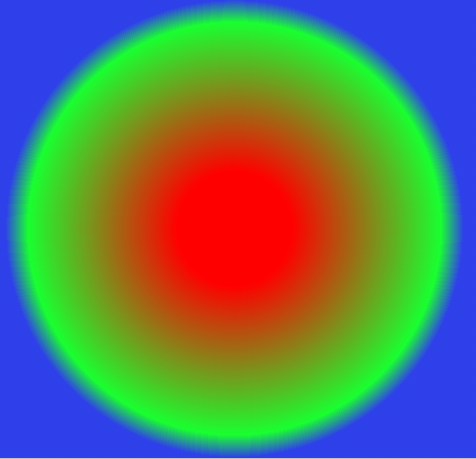

### Components

chemical formula used to describe the composition of a phase

example: alkaline feldspar (f$_{sp}$)

Composition: Na$_{0.5}$K$_{0.5}$AlSi$_3$O$_8$

Components: can use different units, below are three versions of the same information, typically we choose the option with the smallest number of components (aka the last option here)

| Element | Atom % |
| --- | --- |
| Na | 3.85 |
| K | 3.85 |
| Al | 7.70 |
| Si | 23.08 |
| O | 61.54 |

| Oxides | Mol % |
| --- | --- |
| K$_2$O | 6.25 |
| Na$_2$O | 6.25 |
| Al$_2$O$_2$ | 12.50 |
| SiO$_2$ | 75.00 |

| f$_sp$ molecules | mol % |
| --- | --- |
| KAlSi$_3$O$_8$ | 50 |
| NaAlSi$_3$O$_8$ | 50 |

# Definitions

$R^{x}=\frac{^xA}{^yA}$ where $x$ is the rare isotope of the element $A$ and $y$ is the common isotope

$^x\alpha_{A/B}=R^x_{A}/R^x_{B}=(^x\alpha^{Eq}_{A/B}-^x\alpha^{Kin}_{A/B})\frac{\phi_{B/A}}{\phi_{A/B}}+^x\alpha^{Kin}_{A/B}$ where A and B are two compounds (reactant/product etc)

$\frac{\phi_{B/A}}{\phi_{A/B}}=e^{\frac{\Delta G_r}{RT}}$